# Load Data

```python
import pandas as pd

health_data = pd.read_csv('https://storage.googleapis.com/datalynn-datasets/interview-challenge/technology/Apple_Health/HealthData.csv')
```

## Question 1

**Scenario**: Given the increasing popularity of the Health app, a considerable volume of health data is available. From this data, we want to understand users' fitness habits.

**Question**: From the `HealthData` table, load the last three months of data and segment users based on the average number of `Steps` they take and the total `Duration` of their activities. What can you infer about the different segments of users in terms of their health habits?

## Solution

### Hints:

1. **Data Manipulation & Cleaning**:
   - Filter the dataset to retain only the last three months of data.
   - Check for appropriate data types and missing values in `HealthData`.
2. **User Segmentation**:
   - Calculate average steps and total activity duration for each user.
   - Segment users into defined groups based on average steps and activity duration.
3. **Visualization & Analysis & Interpretation**:
   - Plot the segmentation.
   - Examine the characteristics of each segment.
   - Infer health habits of each user group based on the segment they fall into.

### Step 1: Data Manipulation & Cleaning:

```python
# Data cleaning - Checking for missing values in query_data
print(health_data.isnull().sum())

# Checking data types
print(health_data.dtypes)
```

```
UserID                  0
Timestamp               0
Activity                0
Duration                0
HeartRate               0
Steps                   0
Calories                0
SleepHours              0
StudyID               170
StudyParticipation      0
dtype: int64
UserID                 object
Timestamp              object
Activity               object
Duration                int64
HeartRate               int64
Steps                   int64
Calories                int64
SleepHours            float64
StudyID                object
StudyParticipation     object
dtype: object
```

```python
# Python imports
import matplotlib.pyplot as plt
from datetime import datetime, timedelta

# Convert the Timestamp column to datetime:
health_data['Timestamp'] = pd.to_datetime(health_data['Timestamp'])

# Filtering for the last three months of data
end_date = health_data['Timestamp'].max()
start_date = end_date - timedelta(days=90)
filtered_data = health_data[(health_data['Timestamp'] >= start_date) & (health_data['Timestamp'] <= end_date)]

# This block filters the dataset to include only the last three months of data.
# It first identifies the maximum timestamp (latest date) and subtracts 90 days to get the start date.

print("\nEarliest date in filtered data:", filtered_data['Timestamp'].min())
print("Latest date in filtered data:", filtered_data['Timestamp'].max())
```

```
Earliest date in filtered data: 2023-05-24 16:38:00
Latest date in filtered data: 2023-08-22 16:00:00
```

### Step 2: User Segmentation:

**1. Calculate average steps and total activity duration for each user.**

```python
# Calculate average number of steps and total duration for each user
user_summary = filtered_data.groupby('UserID').agg(Avg_Steps=('Steps', 'mean'), Total_Duration=('Duration', 'sum')).reset_index()

# The code above groups the data by UserID and then computes two metrics:
# average steps (Avg_Steps) and total duration of activities (Total_Duration).

# Segmenting users based on criteria
step_threshold = user_summary['Avg_Steps'].mean()
duration_threshold = user_summary['Total_Duration'].mean()

# The two lines above calculate the average number of steps and average duration across all users.
# These values will serve as thresholds to segment our users.

print("\nStep Threshold:", step_threshold)
print("Duration Threshold:", duration_threshold)
```

```
Step Threshold: 4550.022494887526
Duration Threshold: 84.6482617586912
```

**2. Segment users into defined groups based on average steps and activity duration.**

```python
def segment_users(row):
    if row['Avg_Steps'] > step_threshold and row['Total_Duration'] > duration_threshold:
        return 'High Steps & High Duration'
    elif row['Avg_Steps'] > step_threshold and row['Total_Duration'] <= duration_threshold:
        return 'High Steps & Low Duration'
    elif row['Avg_Steps'] <= step_threshold and row['Total_Duration'] > duration_threshold:
        return 'Low Steps & High Duration'
    else:
        return 'Low Steps & Low Duration'

user_summary['Segment'] = user_summary.apply(segment_users, axis=1)

# The segment_users function assigns users to one of four categories, based on their average steps and total duration.
print("\nUser Segment Counts:")
print(user_summary['Segment'].value_counts())

print("\nSample of Segmented Data:")
for segment in user_summary['Segment'].unique():
    print(f"\n{segment} Users:")
    print(user_summary[user_summary['Segment'] == segment].head(3))
```

```
User Segment Counts:
Low Steps & Low Duration      446
High Steps & High Duration    280
High Steps & Low Duration     127
Low Steps & High Duration     125
Name: Segment, dtype: int64

Sample of Segmented Data:

High Steps & High Duration Users:
   UserID  Avg_Steps  Total_Duration                     Segment
0  U00023    12528.0             116  High Steps & High Duration
4  U00027     8192.0             128  High Steps & High Duration
8  U00031    12555.0              93  High Steps & High Duration

High Steps & Low Duration Users:
    UserID  Avg_Steps  Total_Duration                    Segment
1   U00024     8618.0              62  High Steps & Low Duration
12  U00035    10920.0              84  High Steps & Low Duration
14  U00037     6885.0              81  High Steps & Low Duration

Low Steps & Low Duration Users:
   UserID  Avg_Steps  Total_Duration                   Segment
2  U00025      260.0              65  Low Steps & Low Duration
3  U00026     3175.0              25  Low Steps & Low Duration
6  U00029     1690.0              65  Low Steps & Low Duration

Low Steps & High Duration Users:
    UserID  Avg_Steps  Total_Duration                    Segment
5   U00028     4056.0             104  Low Steps & High Duration
7   U00030     3476.0             158  Low Steps & High Duration
27  U00050     2256.0              94  Low Steps & High Duration
```

### Step 3: Visualization & Analysis & Interpretation:

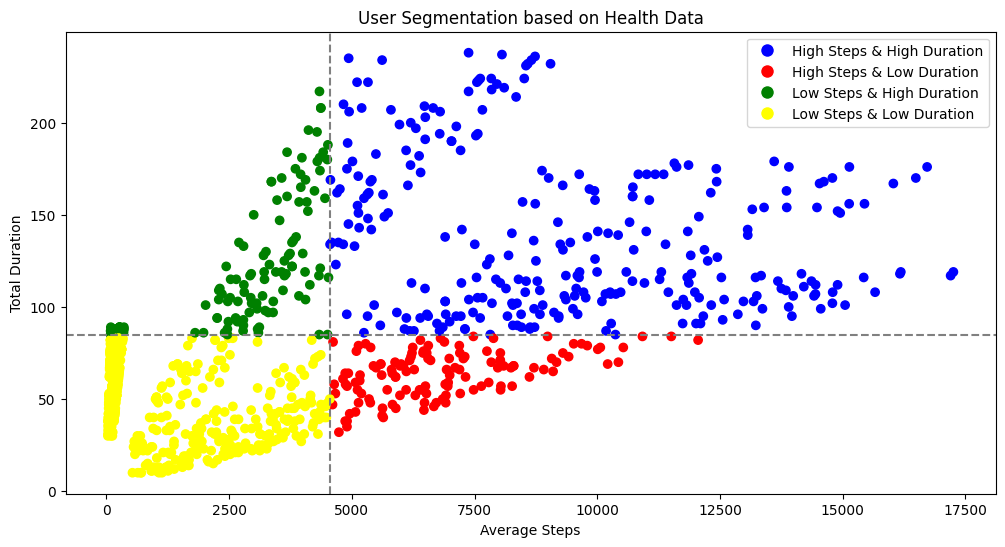

```python
# Plotting the segmentation
plt.figure(figsize=(12, 6))
colors = {"High Steps & High Duration": "blue", "High Steps & Low Duration": "red", "Low Steps & High Duration": "green", "Low Steps & Low Duration": "yellow"}
user_summary['Segment_Colors'] = user_summary['Segment'].map(colors)

plt.scatter(user_summary['Avg_Steps'], user_summary['Total_Duration'], c=user_summary['Segment_Colors'], label=user_summary['Segment'])
plt.axhline(duration_threshold, color='gray', linestyle='--')
plt.axvline(step_threshold, color='gray', linestyle='--')
plt.xlabel('Average Steps')
plt.ylabel('Total Duration')
plt.title('User Segmentation based on Health Data')
plt.legend(handles=[plt.Line2D([0], [0], marker='o', color='w', label=seg, markersize=10, markerfacecolor=colors[seg]) for seg in colors])
plt.show()

# This block visualizes users' positions based on their average steps and total duration.
# The dotted lines represent the thresholds used to segment the users.
```

**Comments on the Result**:

The scatter plot provides a clear view of where each user stands in terms of average steps and total duration:

1. Users in the blue quadrant (High Steps & High Duration) seem to have a consistent fitness routine, engaging in longer, step-centric activities.
2. The red quadrant users (High Steps & Low Duration) probably emphasize more on short, high-intensity workouts.
3. The green quadrant (Low Steps & High Duration) likely contains those who focus on non-step-centric activities like yoga.
4. The yellow quadrant users (Low Steps & Low Duration) may need more encouragement or might have activities that aren't captured accurately as steps.

## Question 2

**Scenario**: Apple wants to improve its Health app by tailoring features to different types of users. Understanding sleep patterns is essential to make app recommendations and improve user health.

**Question**: Compute the average `SleepHours` for users participating in clinical studies (`StudyParticipation` = yes) versus those who do not. Using statistical tests, determine if there's a significant difference in sleep patterns between these two groups.

## Solution

### Hints:

1. **Calculate Average SleepHours**:
   - Filter data based on `StudyParticipation` status (yes/no).
   - Compute the mean of SleepHours for both groups.
2. **Statistical Test for Difference**:
   - We can use the Independent Samples t-test to compare the means of the two groups.
   - The null hypothesis (*H*0) will be that there's no difference in sleep patterns between the two groups. The alternative hypothesis (*H*1) will be that there's a significant difference.
3. **Interpretation**:
   - Interpret the results of the statistical test.
   - Comment on any significant findings.

### Step 1: Calculate Average SleepHours:

```python
study_group = health_data[health_data['StudyParticipation'] == 'yes']['SleepHours'].mean()
non_study_group = health_data[health_data['StudyParticipation'] == 'no']['SleepHours'].mean()

print("Average Sleep Hours for Study Group:", study_group)
print("Average Sleep Hours for Non-Study Group:", non_study_group)
```

```
Average Sleep Hours for Study Group: 7.103530120481928
Average Sleep Hours for Non-Study Group: 6.982
```

### Step 2: Statistical Test for Difference:

```python
from scipy.stats import ttest_ind

## To determine if there's a significant difference in sleep patterns between the two groups, we'll use the Independent Samples t-test.
# Filter data for both groups
study_sleep = health_data[health_data['StudyParticipation'] == 'yes']['SleepHours']
non_study_sleep = health_data[health_data['StudyParticipation'] == 'no']['SleepHours']

# Conduct t-test
t_stat, p_value = ttest_ind(study_sleep, non_study_sleep)

print("T-statistic:", t_stat)
print("P-value:", p_value)
```

```
T-statistic: 0.8375326434913098
P-value: 0.40249375606776405
```

### Step 3: Interpretation:

```python
alpha = 0.05  # Common significance level (confidence interval - 95%)
if p_value < alpha:
    print("There's a significant difference in sleep patterns between the study and non-study groups.")
else:
    print("There's no significant difference in sleep patterns between the study and non-study groups.")
```

```
There's no significant difference in sleep patterns between the study and non-study groups.
```

Note: If the p-value is less than our significance level (e.g., 0.05), then we can reject the null hypothesis and conclude that there is indeed a significant difference in sleep patterns between users who participate in studies and those who don't. Otherwise, we would accept the null hypothesis.

**Comment**

The lack of significant difference suggests that participation in clinical studies (as recorded in the Health app) doesn't notably affect the sleep patterns of the users.

This can mean a couple of things:

- The studies they're participating in might not be related to sleep or affecting their sleep in any significant manner.
- The Health app's influence or any recommendations provided might not be altering sleep behavior for those in studies compared to those not in studies.

## Question 3

**Scenario**: A new version of the Health app was recently released. Apple wants to determine if the app update increased users' participation in clinical studies.

**Question**: Conduct an A/B test where Group A comprises users on the old version and Group B includes users on the new version. Using the `StudyParticipation` column, determine if there's a significant increase in study participation in Group B.

## Solution

### 1. **Experiment Design**:

#### A/B Testing:

- **Control Group (A)**: Users on the old version of the Health app.
- **Treatment Group (B)**: Users on the new version of the Health app.

Randomly assign users to these groups, ensuring even distribution to prevent any biases.

### 2. **Metrics to Measure**:

- **Primary Metric**: Study Participation Rate. This will indicate whether users on the new app version are more inclined to take part in clinical studies.
- **Secondary Metrics**:
  - Activity: Types and frequency of activities logged, to understand if users are more active in one group.
  - Engagement: This can be measured by other metrics such as heart rate, steps, calories, etc., to see if users are engaging more with the app in one group.

### 3. **Duration of the Experiment**:

Considering the importance of the update and the need to gather a significant amount of data for conclusive results, the experiment should run for at least a few weeks or until a statistically significant number of users have participated.

### 4. **Analysis**:

After the data collection period, conduct a Chi-square test to compare the study participation rates between Groups A and B.

- If Group B shows a statistically significant higher participation rate than Group A, this suggests the new app version encourages more users to participate in clinical studies.

### 5. **Other Considerations**:

- **Feedback Review**: Going beyond numbers, analyze any user feedback regarding the new features or changes in the app. This might give insights into why there's an increase or lack thereof in study participation.
- **Segment Analysis**: It's beneficial to analyze the behavior of various user segments - for instance, users who frequently log activities vs. those who don't. Such segments might have different responses to the app update.
- **Ensure Stability**: Guarantee that no other significant updates or changes are introduced during the test to maintain the experiment's integrity.

### 6. **Conclusion**:

Should the data indicate that the new app version led to increased clinical study participation, then Apple can confidently roll out the update to all users. However, if there's no significant difference, or if participation decreases, Apple might need to revisit the app's features or the manner they're presented. Regardless of the outcome, continue to monitor user behavior and feedback to ensure sustained positive impact.

## Question 4

**Scenario**: Apple is partnering with health professionals to design a new study related to heart health. For this, understanding the correlation between activities and heart rate is essential.

**Question**: Analyze the relationship between `Activity` and average `HeartRate` for each activity. Which activity leads to the highest average heart rate? How does this vary amongst different user segments in question 1? For the next phase, use this information to recommend potential users that can be targeted for the heart health study.

## Solution

### Hints:

1. **Activity & HeartRate Analysis**:
   - Group the data by `Activity` and compute the average `HeartRate` for each activity.
   - Identify the activity with the highest average `HeartRate`.
2. **Segmented User Analysis**:
   - Integrate the user segments into the main `HealthData` table.
   - Analyze the average HeartRate across different activities within each user segment.
3. **Recommendations for Heart Health Study**:
   - For each user, identify activities where their heart rate is significantly (1.2 times) higher than the average for that activity.

### Step 1: Activity & HeartRate Analysis:

```python
# 1. Group the data by Activity and compute the average HeartRate for each activity.
activity_heart_rate = health_data.groupby('Activity')['HeartRate'].mean().reset_index(name='Overall_Avg_HeartRate')

# 2. Identify the activity with the highest average HeartRate.
top_activity = activity_heart_rate.sort_values(by='Overall_Avg_HeartRate', ascending=False).iloc[0]
print(activity_heart_rate)
print(f"\nThe activity with the highest average heart rate is {top_activity['Activity']} with an average heart rate of {top_activity['Overall_Avg_HeartRate']:.2f}.\n")
```

```
  Activity  Overall_Avg_HeartRate
0  cycling             109.475610
1  running             118.970037
2  walking              79.160000
3     yoga              65.139241

The activity with the highest average heart rate is running with an average heart rate of 118.97.
```

### Step 2: Segmented User Analysis:

```python
# 3. Integrate the user segments into the main HealthData table.
merged_data = pd.merge(health_data, user_summary[['UserID', 'Segment']], on='UserID', how='left')

# Merge the Overall_Avg_HeartRate to the merged_data
merged_data = pd.merge(merged_data, activity_heart_rate, on='Activity', how='left')

# 4. Analyze the average HeartRate across different activities within each user segment.
segment_activity_hr = merged_data.groupby(['Segment', 'Activity'])['HeartRate'].mean().reset_index()
segment_activity_hr = pd.merge(segment_activity_hr, activity_heart_rate, on='Activity')
segment_activity_hr['Difference_From_Overall'] = segment_activity_hr['HeartRate'] - segment_activity_hr['Overall_Avg_HeartRate']

for segment in segment_activity_hr['Segment'].unique():
    print(f"\nAverage HeartRate and its Difference From Overall Average for {segment} Users:")
    subset = segment_activity_hr[segment_activity_hr['Segment'] == segment].sort_values(by='HeartRate', ascending=False)
    print(subset[['Activity', 'HeartRate', 'Overall_Avg_HeartRate', 'Difference_From_Overall']])
```

```
Average HeartRate and its Difference From Overall Average for High Steps & High Duration Users:
  Activity   HeartRate  Overall_Avg_HeartRate  Difference_From_Overall
3  running  119.039474             118.970037                 0.069436
0  cycling  109.770270             109.475610                 0.294661
6  walking   79.815385              79.160000                 0.655385

Average HeartRate and its Difference From Overall Average for Low Steps & High Duration Users:
   Activity  HeartRate  Overall_Avg_HeartRate  Difference_From_Overall
1   cycling  107.27551             109.475610                -2.200100
8   walking   82.00000              79.160000                 2.840000
10     yoga   66.52000              65.139241                 1.380759

Average HeartRate and its Difference From Overall Average for Low Steps & Low Duration Users:
   Activity   HeartRate  Overall_Avg_HeartRate  Difference_From_Overall
5   running  118.655556             118.970037                -0.314482
2   cycling  110.909091             109.475610                 1.433481
9   walking   79.112500              79.160000                -0.047500
11     yoga   64.933333              65.139241                -0.205907

Average HeartRate and its Difference From Overall Average for High Steps & Low Duration Users:
  Activity   HeartRate  Overall_Avg_HeartRate  Difference_From_Overall
4  running  119.368421             118.970037                 0.398384
7  walking   76.250000              79.160000                -2.910000
```

**High Steps & High Duration Users:**

- Slightly elevated heart rates for running and cycling. Walking showed the most noticeable deviation above average. No yoga data.

**High Steps & Low Duration Users:**

- Running had a heart rate above average. Walking's heart rate was significantly lower than the average. No data for cycling and yoga.

**Low Steps & High Duration Users:**

- Cycling had a heart rate below average. Walking and yoga heart rates were above average. No running data.

**Low Steps & Low Duration Users:**

- Minor deviations from the average for all activities. Cycling's heart rate was slightly above average.

### Step 3: Recommendations for Heart Health Study:

```python
# 5. For each user, identify activities where their heart rate is significantly higher than the average for that activity.
threshold_percentage = 0.20
merged_data['Above_Avg'] = merged_data['HeartRate'] > (1 + threshold_percentage) * merged_data['Overall_Avg_HeartRate']

recommended_users = merged_data[merged_data['Above_Avg']]
print("\nRecommended users for the heart health study based on activities where their heart rate is significantly higher than average:")
print(recommended_users[['UserID', 'Activity', 'HeartRate', 'Overall_Avg_HeartRate']])
```

```
Recommended users for the heart health study based on activities where their heart rate is significantly higher than average:
     UserID Activity  HeartRate  Overall_Avg_HeartRate
8    U00009     yoga         79              65.139241
19   U00020  cycling        137             109.475610
39   U00040  walking         99              79.160000
40   U00041  running        149             118.970037
46   U00047  running        143             118.970037
..      ...      ...        ...                    ...
938  U00939     yoga         79              65.139241
939  U00940  walking         99              79.160000
943  U00944  running        147             118.970037
966  U00967  walking         98              79.160000
985  U00986     yoga         79              65.139241

[99 rows x 4 columns]
```

**Comments on the Result:**

By identifying and recommending users who participate in the activity with heart rates 1.2 times higher than average, Apple can effectively target users who are most relevant for their heart health study. This data-driven approach ensures a more focused and efficient user recruitment for the study.